# 阶跃函数的谱

邹俊杰

2016年11月14日

# 0 library

```r
library(ggplot2)
library(stats)
library(base)
library(gridExtra)
```

# 1 基础概念

傅里叶分析包含傅里叶级数与傅里叶变换。傅里叶级数用于对周期信号转换，傅里叶变换用于对非周期信号转换。但是对于不收敛信号，傅里叶变换无能为力，只能借助拉普拉斯变换。（主要用于计算微分方程）。而z变换则可以算作离散的拉普拉斯变换。（主要用于计算差分方程）。

## 1.1 傅里叶变换与拉普拉斯变换的关系

连续时间傅里叶变换的公式是： $\int_{-\infty}^{\infty } x(t)e^{-jwt} dt,$ 这里的$w$是实数。

傅里叶变换要求时域信号绝对可积，即 $\int_{-\infty }^{\infty } | x(t) | dt<\infty,$  
为了让不符合这个条件的信号，也能变换到频率域，我们给x(t)乘上一个指数函数$e^{-\sigma t}$ ，$\sigma$ 为任意实数。

可以发现，$x(t)e^{-\sigma t}$ 这个函数，就满足了绝对可积的条件，即 $\int_{-\infty }^{\infty } \left| x(t)e^{-\sigma t} \right| dt<\infty,$

于是这个新函数的傅立叶变换就是： $\int_{-\infty }^{\infty } x(t)e^{-\sigma t} e^{-j\omega t} dt,$  
化简得 $\int_{-\infty }^{\infty } x(t)e^{-(\sigma +j\omega )t}$

显然$\sigma +j\omega$是一个复数，我们把这个复数定义为一个新的变量——复频率，记为s。于是便得到了拉普拉斯变换的公式： $\int_{-\infty }^{\infty } x(t)e^{-st} dt$

拉普拉斯变换解决了不满足绝对可积条件的连续信号，变换到频率域的问题，同时也对“频率”的定义进行了扩充。

所以拉普拉斯变换与连续时间傅里叶变换的关系是：拉普拉斯变换将频率从实数推广为复数，因而傅里叶变换变成了拉普拉斯变换的一个特例。当s为纯虚数时，x(t)的拉普拉斯变换，即为x(t)的傅里叶变换。

另外，以上提到为双边拉氏变换，其收敛域可能为空。我们常用的是单边拉氏变换，他的收敛域必定非空。我们研究因果关系，主要关注 $t>0$ 的系统响应，即便 $t<0$ 网络内部有储能，但其影响可以用 $t=0$ 时的初始条件表征。所以初始条件与 $t\ge 0$ 的激励已经能够完全确定 $t>0$ 的系统响应。

## 1.2 广义傅里叶变换

把原来不满足绝对可积的信号，通过乘上收敛因子取代极限的办法而求得的傅立叶变换，称为广义傅立叶变换。

## 1.3 功率谱与频谱，能量谱

**功率谱**是随机过程的统计平均概念，平稳随机过程的功率谱是一个确定函数；

**频谱**是随机过程样本的Fourier变换，对于一个随机过程而言，频谱也是一个“随机过程”。包含了幅值和相位信息。

**能量谱**是频谱模的平方。能量谱密度的定义适用于能量集中在一个时间窗口附近的瞬变（脉冲状信号）。平稳信号持续无限长时间。这就是在这些情况下不能使用上面定义的能量谱密度的原因。

通常所指的能量谱和能量谱密度是一个概念；功率谱和功率谱密度是一个概念，而且功率是指平均功率。

功率谱可以从两方面来定义，一个是自相关函数的傅立叶变换，另一个是时域信号傅氏变换模平方然后除以时间长度。第一种定义就是常说的维纳辛钦定理，而第二种其实从能量谱密度来的。根据parseval定理，信号傅氏变换模平方被定义为能量谱，能量谱密度在时间上平均就得到了功率谱。

平稳信号功率谱密度恰好是其自相关函数的傅氏变换。对于非平稳信号，其自相关函数的时间平均（对时间积分，随时变性消失而再次退变成一维函数）与功率谱密度仍是傅氏变换对；

当信号在$t \in (-\infty,\infty)$的平均功率有限时，能量是无限的；当信号在$t \in (-\infty,\infty)$的能量有限时，其平均功率为0。能量有限的信号称为能量信号；平均功率有限的信号称为功率信号。

### 1.3.1 频谱

$\lim_{T \to \infty}\hat{f_T}(w)$

### 1.3.2 能量谱密度

$\lim_{T \to \infty}{|\hat{f_T}(w)|}^2$

### 1.3.3 功率谱密度

$\lim_{T \to \infty}\frac{{|\hat{f_T}(w)|}^2}{2T}$

## 1.4 单位阶跃信号

单位阶跃函数，又称赫维赛德阶跃函数，定义如下： $H(x)={\begin{cases}0,&x<0\\{\frac {1}{2}},&x=0\\1,&x>0\end{cases}}$

或 $H(x)={\frac {1}{2}}\left(1+\operatorname{sgn}(x)\right)$

它是个不连续函数，其“微分”是狄拉克 δ 函数。它是一个几乎必然是零的随机变数的累积分布函数。

事实上，$x = 0$ 的值在函数应用上并不重要，可以任意取。这个函数由奥利弗·赫维赛德提出。

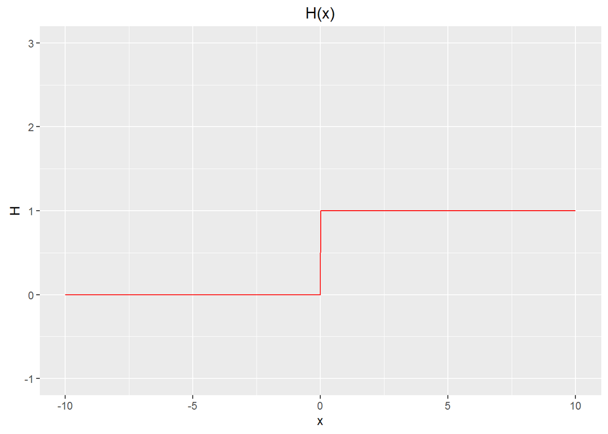

```r
H=function(x){
  if(x<0) {return (0)}
  if(x==0) {return (1/2)}
  if(x>0) {return (1)}
}

x <- seq(-10, 10, by=0.01)
y <- sapply(x,H)
dh <- data.frame(x, y)

g <- ggplot(dh)
g1 <- g + geom_line(col='red',mapping=aes(x,y))+
  xlim(-10,10)+ylim(-1,3)+
  ylab("H")+ggtitle("H(x)")
print(g1)
```

# 2 单位阶跃信号的谱分析

## 2.1 单位直流信号频谱

$x(t)=1$

由于该信号 $t \in (-\infty,\infty)$ ，所以必须乘以双边实指数衰减函数 $e^{-a|t|}$ 以保证信号是绝对可积。

$\begin{aligned} F(1) &= \lim_{a \to 0} F\left(1 \cdot e^{-a|t|} \right) \\ &= \lim_{a \to 0}\int_{-\infty}^{\infty} e^{-a|t|}e^{-jwt} dt \\ &= \lim_{a \to 0}\left(\frac{2a}{a^2+w^2}\right) \\ \end{aligned}$

故有 $F(1)= \begin{cases} 0, &w\neq 0\\ \infty, &w = 0 \end{cases}$

因为 $F(1)$ 在 $w=0$ 处存在 $\delta(w)$ , 其强度为 $\lim_{a \to 0}\left(\frac{2a}{a^2+w^2}\right)=2tg^{-1}(\frac{w}{a})|_{-\infty}^{\infty}=2\pi$

故可以写成 $F(1)=2\pi\delta(w)$

这就是广义傅里叶变换。

## 2.2 符号函数信号(signum)频谱

$x(t)=sgn(t)=\begin{cases} -1, &t<0\\ 0, &t=0\\ 1, &t>0 \end{cases}$

通过广义傅里叶变换，有

$\begin{aligned} F[sgn(t)] &=\lim_{a \to 0}\int_{-\infty}^{\infty} e^{-a|t|}sgn(t)e^{-jwt} dt \\ &=\lim_{a \to 0}\int_{-\infty}^{0}-e^{(a-jw)t}dt+\lim_{a \to 0}\int_{0}^{\infty}e^{-(a+jw)t}dt \\ &=\lim_{a \to 0}\left[\frac{-1}{a-jw}+\frac{1}{a+jw}\right] \\ &=\begin{cases} -j\frac{2}{w}, &w \neq 0\\ 0, &w = 0 \end{cases} \end{aligned}$

## 2.3 单位阶跃信号频谱

$u(t)={\frac {1}{2}}\left(1+sgn(t)\right)$

故 $F[u(t)]=\begin{cases} \frac{1}{2}[2\pi\delta(w)], &w = 0 \\ \frac{1}{2}[2\pi\delta(w)-j\frac{2}{w}], &w \neq 0 \end{cases}$

即 $F[u(t)]=\begin{cases} \pi\delta(w), &w = 0 \\ -j\frac{1}{w}, &w \neq 0 \end{cases}$

## 2.4 单位阶跃信号能量谱密度

$\begin{aligned} E(w)=|F[u(t)]|^2 &=\begin{cases} |\pi\delta(w)|^2, &w = 0 \\ |-j\frac{1}{w}|^2, &w \neq 0 \end{cases} \\ &=\begin{cases} \pi^2\delta^2(w), &w = 0 \\ \frac{1}{w^2}, &w \neq 0 \end{cases} \end{aligned}$

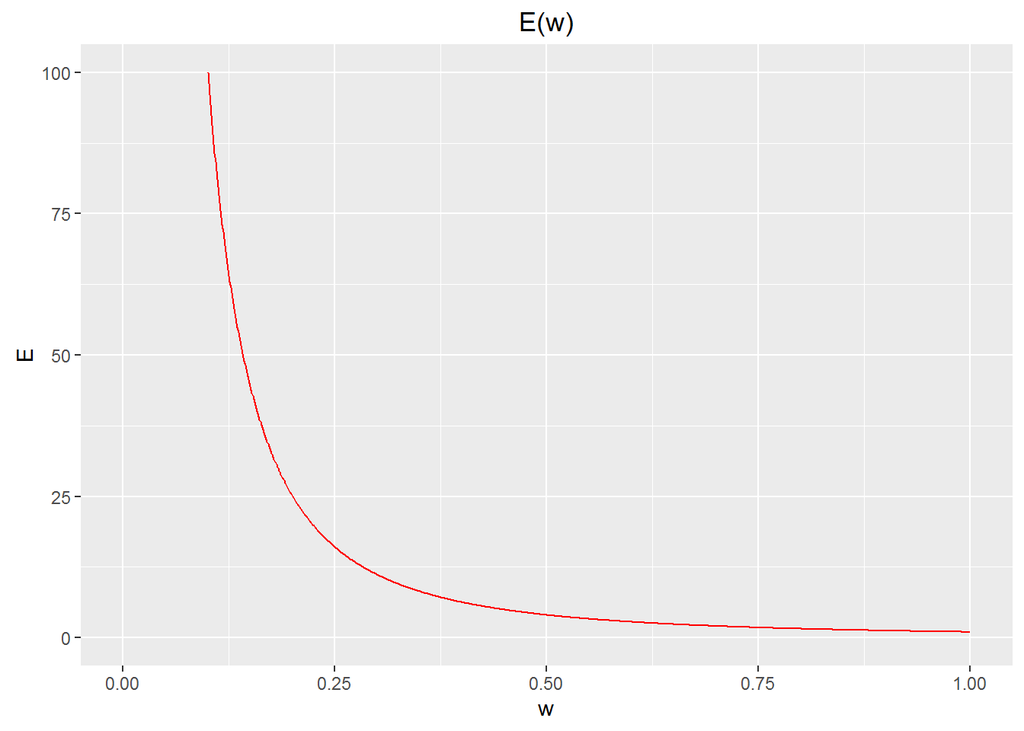

```r
E=function(w){
  if(w==0) {return (Inf)}
  else{return (1/w^2)}
}

w <- seq(0, 1, by=0.001)
y <- sapply(w,E)
dh <- data.frame(w, y)

g <- ggplot(dh)
g1 <- g + geom_line(col='red',mapping=aes(w,y))+
  xlim(0,1)+ylim(0,100)+
  ylab("E")+ggtitle("E(w)")
print(g1)
```

## 2.5 单位阶跃信号频率谱密度

$\mbox{频率谱密度}=\lim_{T \to \infty}\frac{\mbox{能量谱密度}}{T}$

# 3 谱估计

功率谱估计可以分为经典谱估计方法与现代谱估计方法。经典谱估计中最简单的就是周期图法，又分为直接法与间接法。直接法先取N点数据的傅里叶变换（即频谱），然后取频谱与其共轭的乘积，就得到功率谱的估计；间接法先计算N点样本数据的自相关函数，然后取自相关函数的傅里叶变换，即得到功率谱的估计.

- 经典谱估计方法
  - 直接法（周期图法）：先取N点数据的傅里叶变换（即频谱），然后取频谱与其共轭的乘积，就得到功率谱的估计
  - 间接法：先计算N点样本数据的自相关函数，然后取自相关函数的傅里叶变换，即得到功率谱的估计
  - 分段平均周期图法
  - 加窗平均周期图法
- 现代谱估计方法
  - 参数模型谱估计
    - AR模型
    - MA模型
    - ARMA模型等
  - 非参数模型谱估计
    - 最小方差法
    - MUSIC法等

直接法（周期图法），Welth法，Barlett法， 根据定义通过自相关函数求的方法，Cooley-Turkey法

## 3.1 各种谱估计方法的实现

### 3.1.1 直接法（周期图法）

直接法又称周期图法，它是把随机序列x(n)的N个观测数据视为一能量有限的序列，直接计算x(n)的离散傅立叶变换，得X(k)，然后再取其幅值的平方，并除以N，作为序列x(n)真实功率谱的估计。

$\{X_n\}$的傅里叶变化为： $x(w_n) = \sum_{k=0}^{N-1} X_k e^{-i k w_n} \qquad n = 0,\dots,N-1$ 其中 $w_n=\frac{2\pi n}{N}$

$\hat{f}(w_n)=\frac{x(w_n)\cdot \bar{x}(w_n)}{N}$

由于 $\hat{f}(w_n)$ 在 $n = 0,\dots,N-1$ 是对称的，故可去掉后一半。又由于周期图在 0 频率反应的是样本均值，不是周期，在分析问题时通常不予考虑。

```r
direct=function(x,Fs=1){
  N=length(x)
  fft_x=fft(x)
  fft_x_conj=Conj(fft_x)
  y=as.numeric(fft_x_conj*fft_x/N)[1:(N/2+1)][-1]
  w=((1:N-1)*Fs/N)[1:(N/2+1)][-1]
  dh <- data.frame(w, y)
  g <- ggplot(dh)
  g1 <- g + geom_line(col='red',mapping=aes(w,y))+
    scale_y_log10()+
    ylab("f")+ggtitle("直接周期图法")
  return(g1)
}
```

### 3.1.2 间接法

间接法先由序列 $X(n)$ 估计出自相关函数 $\gamma_k$ ，然后对 $\gamma_k$ 进行傅立叶变换，便得到 $X(n)$ 的功率谱估计。

$\hat{f}(w)=-\hat{\gamma_0} + 2\sum_{k=0}^{N-1}\hat{\gamma_k}\cos{wk}$

该估计不是一致的

```r
gamma=function(z){
  Ez=mean(z)
  n=length(z)
  Gamma=array(NA,n-1)
  sum=0
  for(t in 1:n)
    sum=sum+(z[t]-Ez)*(z[t]-Ez)
  Gamma0=1/n*sum

  for(k in 1:(n-1)){
    sum=0
    for(t in 1:(n-k))
      sum=sum+(z[t]-Ez)*(z[t+k]-Ez)
    Gamma[k]=1/n*sum
  }
  return(c(Gamma0,Gamma))
}

indirect=function(a){
  N=length(a)
  Fs=1
  Gamma=gamma(a)
  fft_Gamma=fft(Gamma)
  f=(-Gamma[1]+2*Re(fft_Gamma))[1:(N/2+1)][-1]
  w=((1:N-1)*Fs/N)[1:(N/2+1)][-1]
  y=f
  dh <- data.frame(w, y)
  g <- ggplot(dh)
  g1 <- g + geom_line(col='red',mapping=aes(w,y))+
    scale_y_log10()+
    ylab("f")+ggtitle("间接法")
  return(g1)
}
```

## 3.2各种模型的谱估计

### 3.2.1 高斯白噪声谱估计

#### 生成高斯白噪声

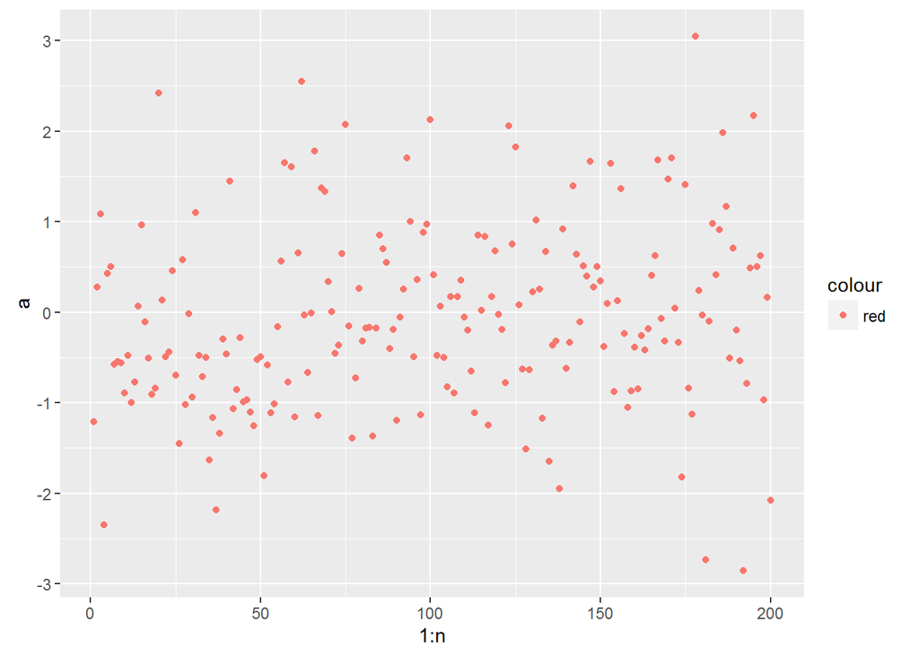

```r
set.seed("1234")
n=200
a=rnorm(n)
qplot(1:n,a,geom = "point",col = "red")
```

#### 高斯白噪声谱估计

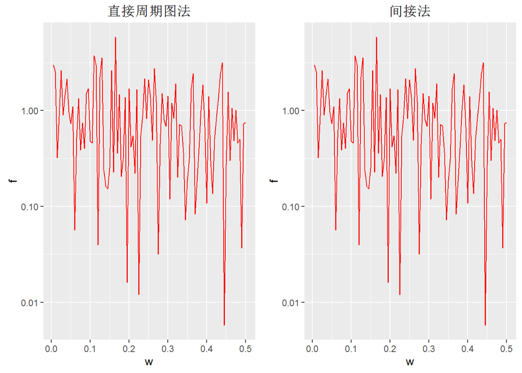

```r
#直接周期图法
grid.arrange(direct(a), indirect(a), nrow=1, ncol=2)
```

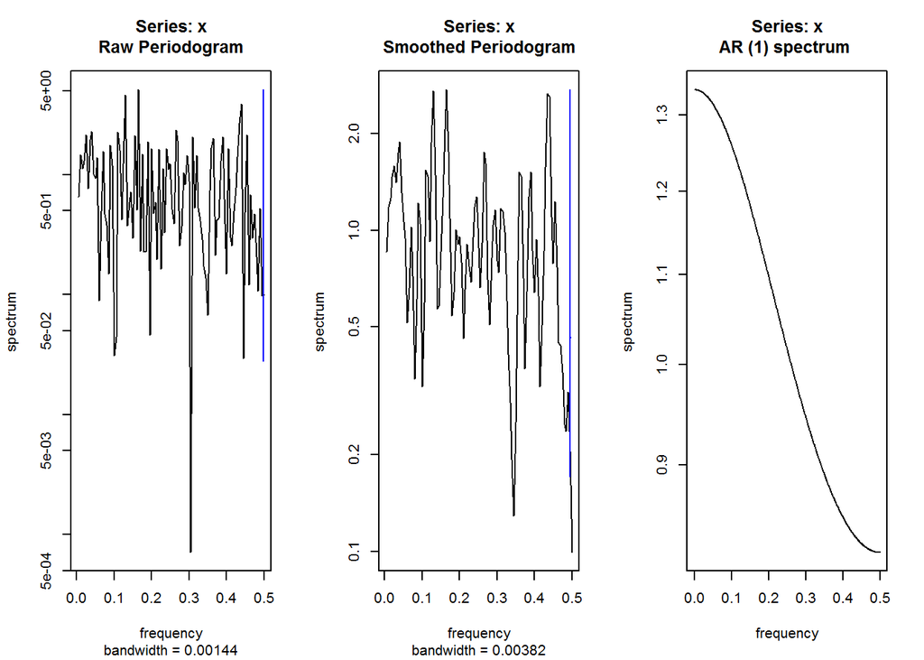

```r
#基础包里的几种算法
par(mfcol=c(1,3))
spectrum(a)
spectrum(a, spans = 3)
spectrum(a,method = "ar")
```

```r
par(mfcol=c(1,1))
```

### 3.2.2 阶跃信号谱估计

#### 生成阶跃信号

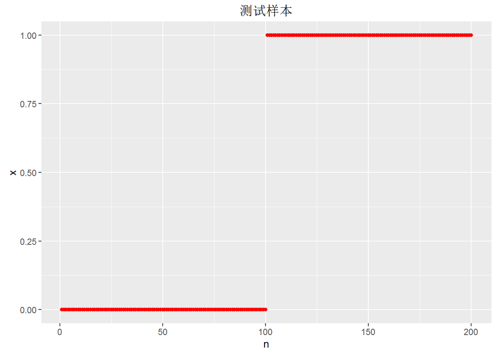

```r
#测试样本
N=200
Fs=1
x = c(rep(0,N/2),rep(1,N/2))
a=data.frame(1:N,x)
g0 <- ggplot(a,mapping = aes(a[,1],a[,2]))+geom_point(col='red')+
  ylab("x")+xlab("n")+ggtitle("测试样本")
print(g0)
```

#### 谱估计

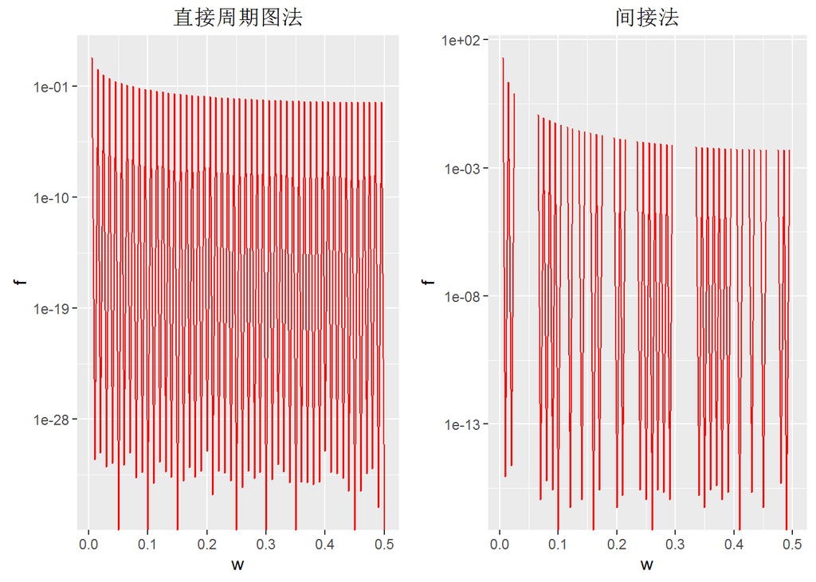

```r
grid.arrange(direct(x), indirect(x), nrow=1, ncol=2)
```

因为有负数产生导致没画出来，为啥间接法会有负数产生,并且都是很小的负数（$10^{-16}$ 量级），是机器误差吗.跟自带函数差别这么大。。

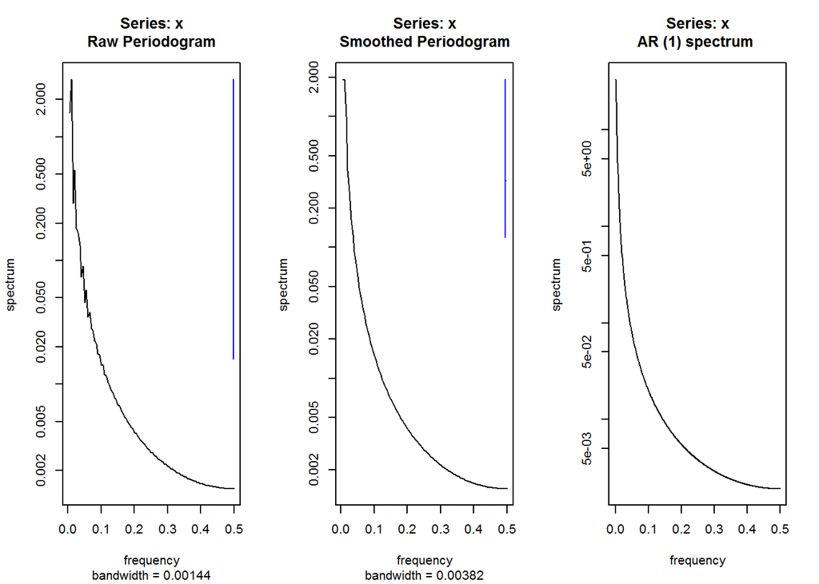

```r
par(mfcol=c(1,3))
spectrum(x)
spectrum(x, spans = 3)
spectrum(x,method = "ar")
```

```r
par(mfcol=c(1,1))
```

### 3.2.3 加有白噪声的阶跃信号谱估计

#### 生成信号

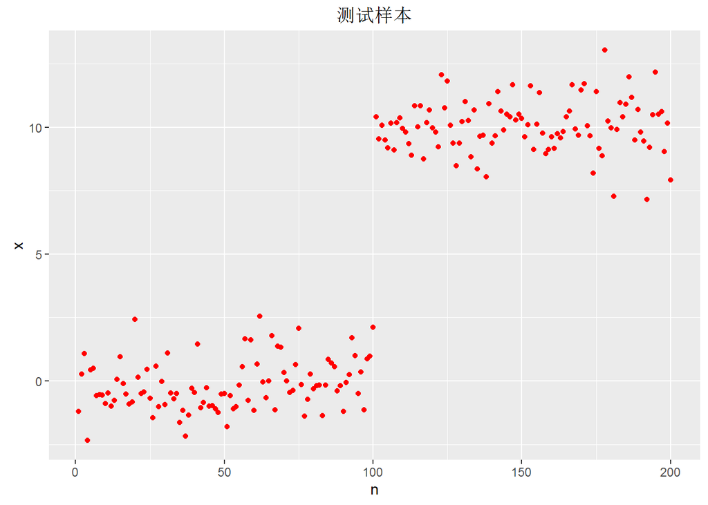

```r
#白噪声
set.seed("1234")
N=200
a=rnorm(N)
#阶跃信号

Fs=1
x = c(rep(0,N/2),rep(10,N/2))
x_a=x+a

a=data.frame(1:N,x_a)
g0 <- ggplot(a,mapping = aes(a[,1],a[,2]))+geom_point(col='red')+
  ylab("x")+xlab("n")+ggtitle("测试样本")
print(g0)
```

#### 谱估计

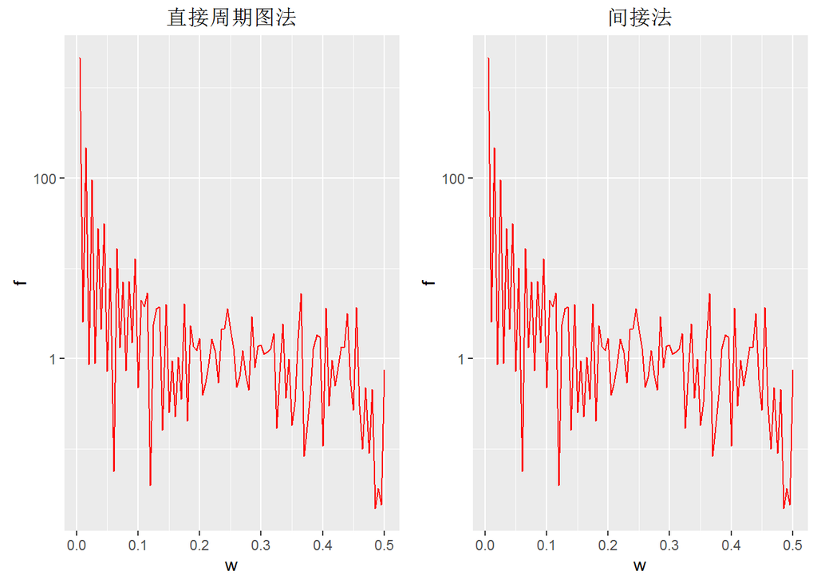

```r
grid.arrange(direct(x_a), indirect(x_a), nrow=1, ncol=2)
```

还是一模一样，应该是计算机机器误差引起的吧

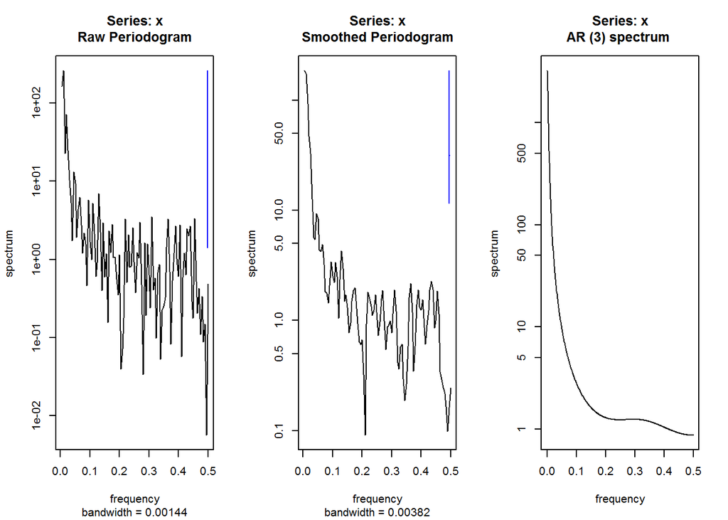

```r
par(mfcol=c(1,3))
spectrum(x_a)
spectrum(x_a, spans = 3)
spectrum(x_a,method = "ar")
```

```r
par(mfcol=c(1,1))
```

### 3.2.4 加有白噪声的尖角信号谱估计

#### 生成信号

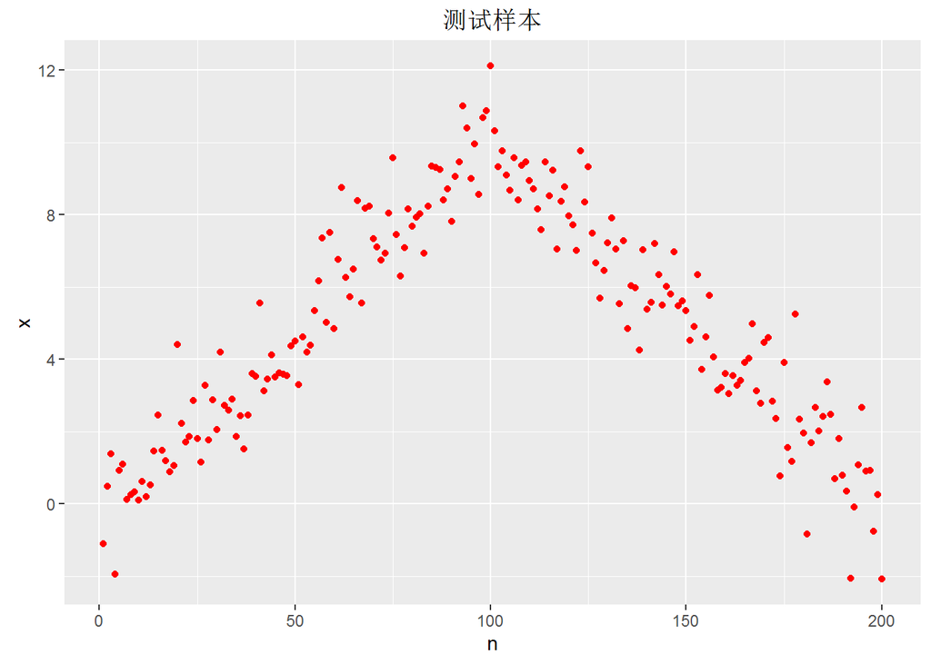

```r
#白噪声
set.seed("1234")
N=200
a=rnorm(N)
#尖角信号

Fs=1
x = c(0.1*(1:100),10-0.1*(1:100))
x_a=x+a

a=data.frame(1:N,x_a)
g0 <- ggplot(a,mapping = aes(a[,1],a[,2]))+geom_point(col='red')+
  ylab("x")+xlab("n")+ggtitle("测试样本")
print(g0)
```

#### 谱估计

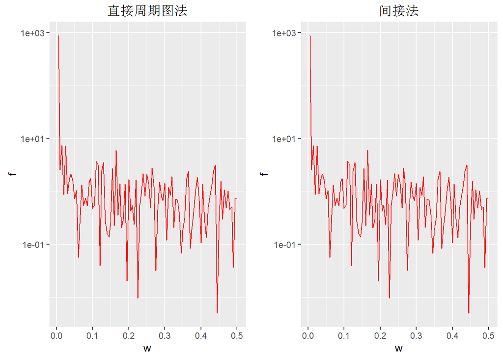

```r
grid.arrange(direct(x_a), indirect(x_a), nrow=1, ncol=2)
```

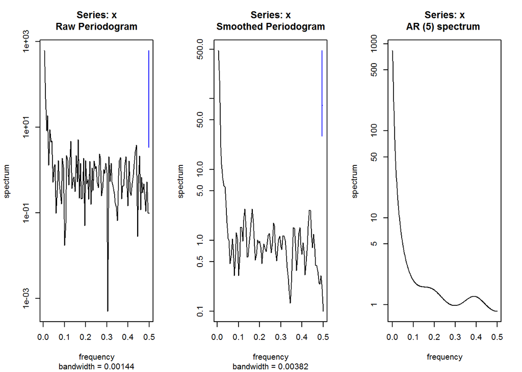

```r
par(mfcol=c(1,3))
spectrum(x_a)
spectrum(x_a, spans = 3)
spectrum(x_a,method = "ar")
```

```r
par(mfcol=c(1,1))
```

# 4参考文献

[傅立叶变换、拉普拉斯变换、Z变换的联系？为什么要进行这些变换。研究的都是什么？](https://www.zhihu.com/question/22085329/answer/103926934)

[单位阶跃函数-维基百科](https://zh.wikipedia.org/wiki/%E5%8D%95%E4%BD%8D%E9%98%B6%E8%B7%83%E5%87%BD%E6%95%B0)

[拉普拉斯变换的物理意义是什么？](https://www.zhihu.com/question/22102732)

[单位直流信号、符号函数信号、阶跃信号与冲激信号](http://wlsyzx.yzu.edu.cn/kcwz/szxhcl/kechenneirong/diyibufen/chapter3_3_1.htm)

[功率谱和频谱的关系](http://www.ilovematlab.cn/thread-305642-1-1.html)

[一种阶跃函数在矩形时间窗口频域特性的分析方法](http://www.epae.cn/ch/reader/create_pdf.aspx?file_no=20131120&flag=1&journal_id=dlzdhsb&year_id=2013)

[信号的频谱、幅度谱、相位谱及能量谱密度、功率谱密度](http://www.cnblogs.com/iliveido/archive/2013/03/22/2976542.html)

[功率谱密度相关方法的MATLAB实现](http://blog.sina.com.cn/s/blog_79ecf6980100vcqn.html)

另： \qquad为letex空格

基础包中所给的谱估计方法为周期图法和AR模型法